# Dominican Republic

meruyert

## Introduction

This report analyzes data from the Demographic and Health Survey (DHS) for the Dominican Republic. DHS surveys are widely used to understand population health, demographic trends, and social inequalities in developing countries.

The main aim of this analysis is to explore how women’s socio-demographic characteristics, such as age, education level, and household wealth, are distributed within the population. These factors are important because they influence health outcomes, access to healthcare, and overall well-being.

## Methods

The dataset used in this analysis comes from the DHS women’s individual recode file for the Dominican Republic. The data were imported into R using the haven package and converted into a usable format.

For this report, a subset of variables was selected, including age (v012), education level (v106), and wealth index (v190). These variables were chosen because they represent key socio-demographic characteristics.

[figure not shown]

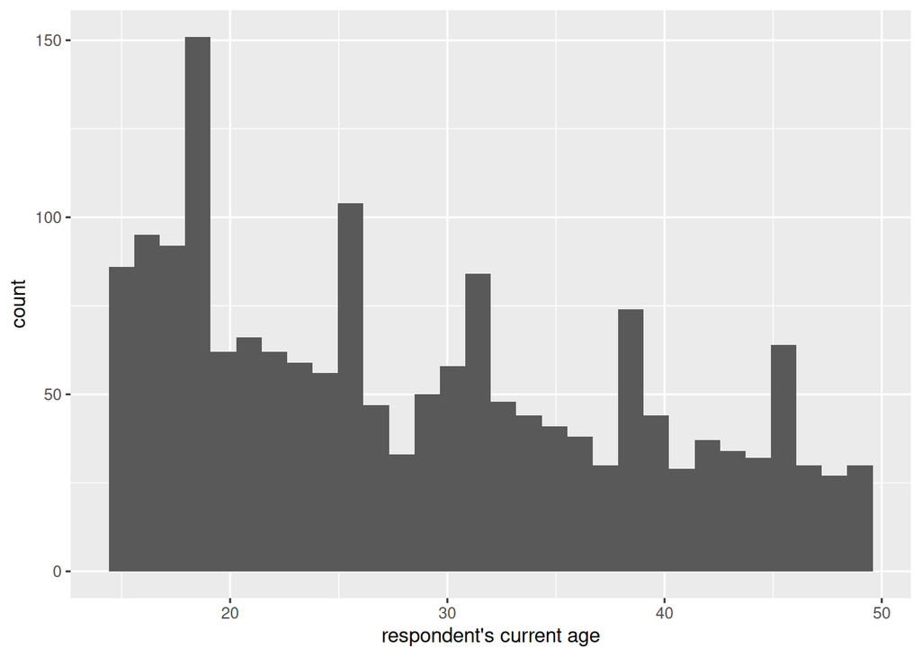

```r
ggplot(dhs, aes(x = v012)) +
  geom_histogram()
```

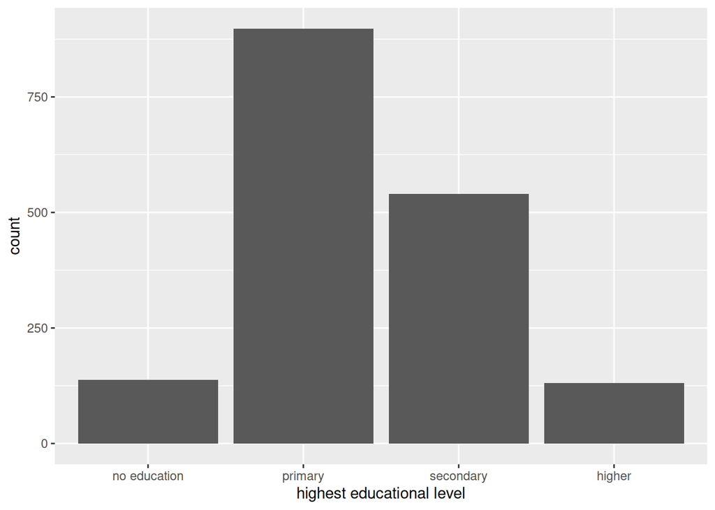

```r
ggplot(dhs, aes(x = v106)) +
  geom_bar()
```

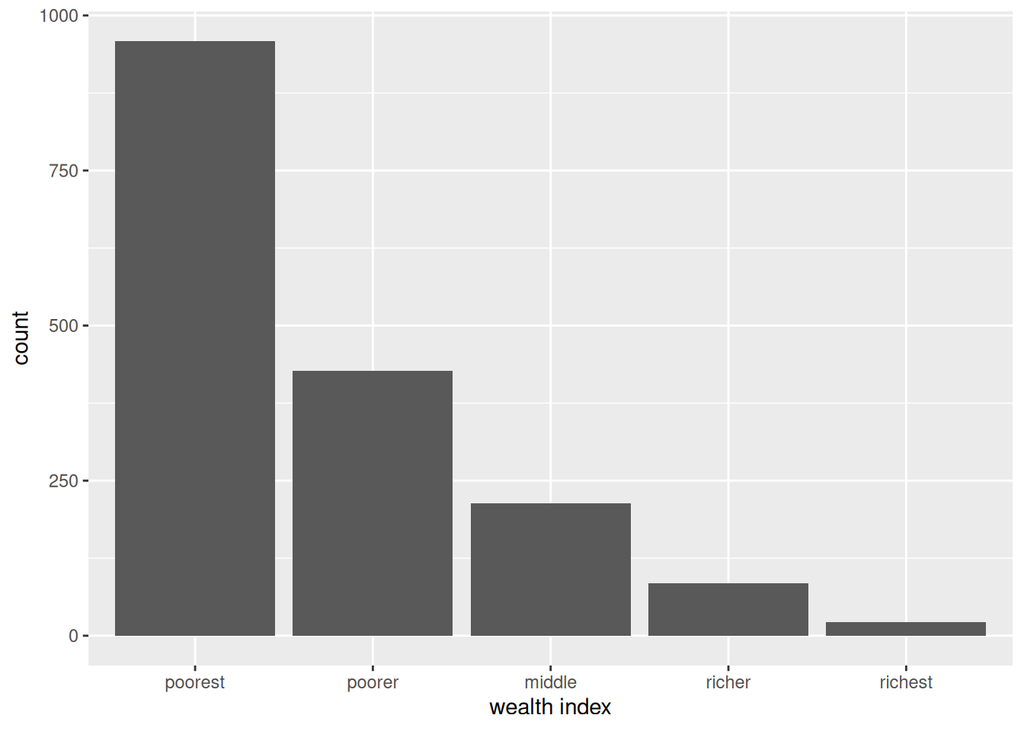

```r
ggplot(dhs, aes(x = v190)) +
  geom_bar()
```

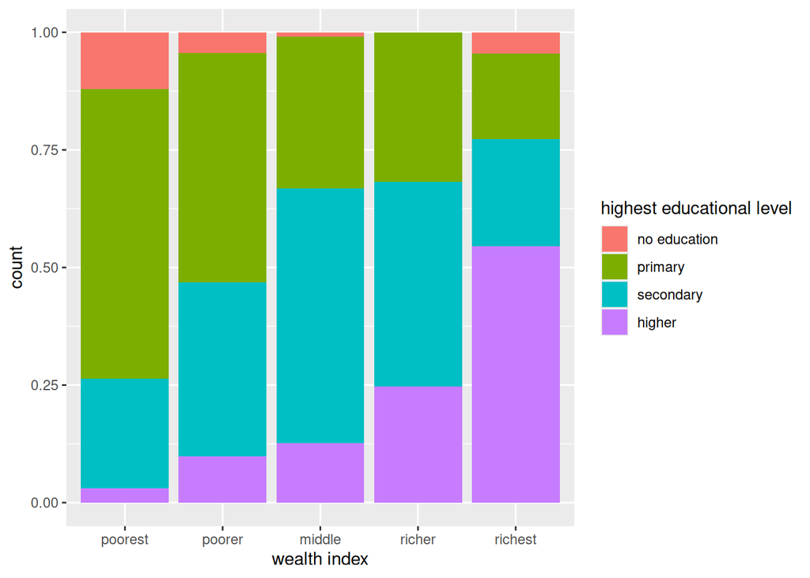

```r
ggplot(dhs, aes(x = v190, fill = v106)) +
  geom_bar(position = "fill")
```

## Conclusion

This analysis highlights important socio-demographic patterns among women in the Dominican Republic. The results show that age, education, and wealth vary across the population and are closely related to each other.

Education appears to be strongly associated with wealth, with women from wealthier households more likely to have higher levels of education. This suggests that economic inequality plays a significant role in access to opportunities.

Understanding these patterns is important for policymakers and public health professionals. Efforts to improve access to education and reduce economic disparities could lead to better health outcomes for women.

Overall, DHS data provide valuable insights that can help guide decision-making and support the development of effective social and health policies.